# Accent Classification on AccentDB with Convolutional Neural Network

# [AccentDB](https://accentdb.github.io/)

```
AccentDB: A Database of Non-Native English Accents to Assist Neural Speech Recognition
Ahamad, Afroz;  Anand, Ankit; Bhargava, Pranesh;
Proceedings of The 12th Language Resources and Evaluation Conference (LREC 2020)
```

We present a baseline model to perform accent classification on a part of our dataset. The dataset consists of audio samples of one speaker for each of the 9 accents from AccentDB.

To keep the Colab simple, we use preprocess numpy vectors for the audio files. These processed vectors are available for download for both the dataset used here and the entire AccentDB Dataset. The vectors can be read directly into a numpy variable, thus eliminating the need to perform complex preprocessing steps.

Follow these links to download the processed vectors.

[Small Dataset](https://github.com/AccentDB/one-speaker-vectors)  
[Large Dataset](https://github.com/AccentDB/database)

Let's begin with the code.

### Download and extract pre-processed numpy vectors

```python
!wget --no-check-certificate --content-disposition https://github.com/AccentDB/one-speaker-vectors/archive/master.zip
!unzip one-speaker-vectors-master.zip
```

```
--2020-05-31 06:39:24--  https://github.com/AccentDB/one-speaker-vectors/archive/master.zip
Resolving github.com (github.com)... 140.82.114.3
Connecting to github.com (github.com)|140.82.114.3|:443... connected.
HTTP request sent, awaiting response... 302 Found
Location: https://codeload.github.com/AccentDB/one-speaker-vectors/zip/master [following]
--2020-05-31 06:39:25--  https://codeload.github.com/AccentDB/one-speaker-vectors/zip/master
Resolving codeload.github.com (codeload.github.com)... 140.82.113.9
Connecting to codeload.github.com (codeload.github.com)|140.82.113.9|:443... connected.
HTTP request sent, awaiting response... 200 OK
Length: unspecified [application/zip]
Saving to: ‘one-speaker-vectors-master.zip’

one-speaker-vectors     [         <=>        ] 219.12M  20.1MB/s    in 11s

2020-05-31 06:39:36 (20.1 MB/s) - ‘one-speaker-vectors-master.zip’ saved [229768661]

Archive:  one-speaker-vectors-master.zip
913a639d20572f0e230b27c41831b302c4e5fddc
   creating: one-speaker-vectors-master/
  inflating: one-speaker-vectors-master/american_speaker_01.files.npy
  inflating: one-speaker-vectors-master/australian_speaker_01.files.npy
  inflating: one-speaker-vectors-master/bangla_speaker_01.files.npy
  inflating: one-speaker-vectors-master/british_speaker_01.files.npy
  inflating: one-speaker-vectors-master/indian_speaker_01.files.npy
  inflating: one-speaker-vectors-master/malayalam_speaker_01.files.npy
  inflating: one-speaker-vectors-master/odiya_speaker_01.files.npy
  inflating: one-speaker-vectors-master/telugu_speaker_01.files.npy
  inflating: one-speaker-vectors-master/welsh_speaker_01.files.npy
```

You should now see a folder titled `one-speaker-vectors-master.zip` in the left pane on this page under the Files menu. This folder is extracted from the `.zip` file of the same name and should contain `.npy` files for each accent.

### Import libraries and set global variables

```python
# from __future__ import print_function
import numpy as np
import datetime, os, random
import tensorflow as tf
import seaborn as sns
from time import time

# Scikit imports for data handling
from sklearn.model_selection import train_test_split
from sklearn.metrics import classification_report

# Keras imports
import keras
from keras.preprocessing import sequence
from keras.models import Sequential
from keras.layers.core import Dense, Dropout, Activation, Flatten
from keras.layers.normalization import BatchNormalization
from keras.layers.convolutional import Convolution1D, MaxPooling1D
from keras.utils import np_utils
from keras.callbacks import TensorBoard
from keras.models import Sequential
from keras.layers import Conv1D, MaxPooling1D
from keras.layers import Activation, Dropout, Flatten, Dense

# for reproducibility
seed = 1337
os.environ['PYTHONHASHSEED'] = str(seed)
np.random.seed(seed)
random.seed(1337)
tf.random.set_seed(seed)

# Load tensorboard and check Tensorfow version
%load_ext tensorboard
logdir = os.path.join("logs", datetime.datetime.now().strftime("%Y%m%d-%H%M%S"))
tensorboard_callback = keras.callbacks.TensorBoard(logdir, histogram_freq=1)
os.environ['TF_CPP_MIN_LOG_LEVEL'] = '3'
print(tf.__version__)
```

```
2.2.0
```

### Load the downloaded vectors

We load the processed vectors for each accent into its corresponding numpy variable. We aso normalize the vectors.

```python
def normalize(v):
  # Suppose your vector is v:
  # 1. First convert it to 2 dimensional for intuitive manipulation
  x = v.shape[1]
  y = v.shape[2]
  v = v.reshape((-1, x * y))
  # 2. Compute norm
  nm = np.linalg.norm(v, axis=1)
  # 3. Reshape it so it can be divided
  nm = nm.reshape((-1,1))
  # 4. Divide
  v = v/nm
  # 5. Get the matrix back
  v = v.reshape((-1, x, y))
  return v

print('Loading data...')

bangla = normalize(np.load("one-speaker-vectors-master/bangla_speaker_01.files.npy"))
malayalam = normalize(np.load("one-speaker-vectors-master/malayalam_speaker_01.files.npy"))
odiya = normalize(np.load("one-speaker-vectors-master/odiya_speaker_01.files.npy"))
telugu = normalize(np.load("one-speaker-vectors-master/telugu_speaker_01.files.npy"))
indian = normalize(np.load("one-speaker-vectors-master/indian_speaker_01.files.npy"))
australian = normalize(np.load("one-speaker-vectors-master/australian_speaker_01.files.npy"))
british = normalize(np.load("one-speaker-vectors-master/british_speaker_01.files.npy"))
american = normalize(np.load("one-speaker-vectors-master/american_speaker_01.files.npy"))
welsh = normalize(np.load("one-speaker-vectors-master/welsh_speaker_01.files.npy"))

print(bangla.shape)
```

```
Loading data...
(778, 499, 13)
```

### Set classification problem labels

We perform accent classification in three settings as described in Table 1 in the [paper](https://www.aclweb.org/anthology/2020.lrec-1.659.pdf).

- Setting 1a: 4-class: Bangla, Mal, Odiya, Telugu
- Setting 1b: 4-class: Australian, British, American, Welsh
- Setting 2: 9-class: Bangla, Mal, Odiya, Telugu, MetroIndian, Australian, British, American, Welsh

```python
# Define categories
samples = {
  "bangla": bangla,
  "malayalam": malayalam,
  "odiya": odiya,
  "telugu": telugu,
  "indian": indian,
  "australian": australian,
  "british": british,
  "american": american,
  "welsh": welsh,

}

indian = ["bangla", "malayalam", "odiya", "telugu"]
non_indian = ["australian", "british", "american", "welsh"]
all_accents = indian + non_indian + ["indian"]
print("Indian accents: ", indian)
print("Non-Indian accents: ", non_indian)
print("All accents: ", all_accents)
```

```
Indian accents:  ['bangla', 'malayalam', 'odiya', 'telugu']
Non-Indian accents:  ['australian', 'british', 'american', 'welsh']
All accents:  ['bangla', 'malayalam', 'odiya', 'telugu', 'australian', 'british', 'american', 'welsh', 'indian']
```

### Prepare the (X, Y) dataset for training

The two functions generate training input and corresponding class labels.

```python
def get_accents(accent_category):
  """
      Get the accents corresponding to the category
  """
  accents = None
  if category == 'indian':
    accents = indian
  elif category == 'non_indian':
    accents = non_indian
  elif category == 'all':
    accents = all

  return accents

def get_data(accent_category):
  """
      Get the data for the accent category
  """
  accents = get_accents(accent_category)
  if accents is None:
    return None

  x = np.zeros((0, 499, 13))
  y = []
  label = 0
  for accent in accents:
    y += (samples[accent].shape[0] * [label])
    x = np.concatenate((x, samples[accent]), axis=0)
    label += 1
  return x, y
```

### Generate training, test and validation splits on the dataset.

```python
# constants
maxlen = 100
nb_filter = 256
filter_length_1 = 10
filter_length_2 = 5
hidden_dims = 750

# split ration of 80:20
split_ratio = 0.20
```

```python
def get_data_splits(x, y):
  """
      Get train, test and validation splits for the data
  """
  nb_classes = 1+int(np.max(y))

  X_train, X_test, y_train, y_test = train_test_split(x, y, test_size=split_ratio, shuffle=True, random_state=seed)
  X_train, X_val, y_train, y_val = train_test_split(X_train, y_train, test_size=split_ratio, shuffle=True, random_state=seed)

  Y_train = keras.utils.to_categorical(y_train, nb_classes)
  Y_test = keras.utils.to_categorical(y_test, nb_classes)
  Y_val = keras.utils.to_categorical(y_val, nb_classes)

  print("Number of classes : ", nb_classes)

  print("\nDATA SPLITS:")
  print("Train: ", X_train.shape[0], "samples")
  print("Test: ", X_test.shape[0], "samples")
  print("Val: ", X_val.shape[0], "samples\n")

  return X_train, X_test, X_val, Y_train, Y_test, Y_val
```

### Define the Convolutional Neural Network Model and view the model summary.

This is the model described in section 3.1.2 in the [paper](https://www.aclweb.org/anthology/2020.lrec-1.659.pdf).

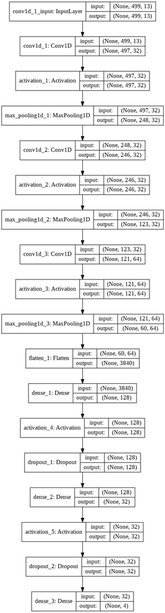

```python
# 499 dimensions are produced by sampling a 5s audio file at 1ms
test_dim = 499
# we use 13 MFCC features in our work
input_shape = (test_dim, 13)

def build_model(nb_classes):
  model = Sequential()
  model = Sequential()
  model.add(Conv1D(32, (3), input_shape=input_shape))
  model.add(Activation('relu'))
  model.add(MaxPooling1D(pool_size=(2)))

  model.add(Conv1D(32, (3)))
  model.add(Activation('relu'))
  model.add(MaxPooling1D(pool_size=(2)))

  model.add(Conv1D(64, (3)))
  model.add(Activation('relu'))
  model.add(MaxPooling1D(pool_size=(2)))

  model.add(Flatten())
  model.add(Dense(128))
  model.add(Activation('relu'))
  model.add(Dropout(0.5))
  model.add(Dense(32))
  model.add(Activation('relu'))
  model.add(Dropout(0.5))
  model.add(Dense(nb_classes, activation='softmax'))

  model.compile(loss='categorical_crossentropy',
                optimizer='rmsprop',
                metrics=['accuracy'])

  return model


test_model = build_model(nb_classes=4)
keras.utils.plot_model(test_model, 'multi_input_and_output_model.png', show_shapes=True)
```

### Define the train function

Set a list of batch_sizes and nb_epochs to train models with different hyperparameters. Different combinations will result in varying performances.

```python
batch_sizes = [32]
nb_epochs = [3]

def train(x, y):
  """
      Train the CNN model
  """
  X_train, X_test, X_val, Y_train, Y_test, Y_val = get_data_splits(x, y)

  nb_train_samples = X_train.shape
  nb_classes = 1+int(np.max(y))

  for batch_size in batch_sizes:
    for nb_epoch in nb_epochs:
      print('Build model...')
      print('Batch Size: ', batch_size, 'and Number of epochs: ', nb_epoch ,'\n')

      model = build_model(nb_classes)
      model.fit(X_train, Y_train, steps_per_epoch=nb_train_samples[0] // batch_size,
              nb_epoch=nb_epoch, shuffle='true', verbose=1, validation_data=(X_val, Y_val),
              validation_steps=1, callbacks=[tensorboard_callback])

      score = model.evaluate(X_test, Y_test, verbose=1)
      print(f"batch_size: {batch_size} epoch: {nb_epoch}", score)
```

### Start the training

The category can be set to reflect the classification setting that is intended to be used. Refer [section on classification settings](https://colab.research.google.com/drive/16I3kgnMpuXqbCoSwaXLHt3Dl-pvPU2rl?authuser=1#scrollTo=4a1bwm0QOJXq&line=7&uniqifier=1).

Category can be `'indian'` (4 class), `'non_indian'` (4 class) and `'all'` (9 class).

```python
category = 'indian' # or 'non_indian', or 'all'
print("Accent category : ", category)

(x, y) = get_data(category)
print("\nTraining data successfully loaded.")

print("Training...")
model = train(x, y)
print("\nTraining done.")
```

```
Accent category :  indian

Training data successfully loaded.
Training...
Number of classes :  4

DATA SPLITS:
Train:  1946 samples
Test:  609 samples
Val:  487 samples

Build model...
Batch Size:  32 and Number of epochs:  3
```

```
Train on 1946 samples, validate on 487 samples
batch_size: 32 epoch: 3 [0.004732886603796374, 0.9983579516410828]

Training done.
```

### Visualize the training process through tensorboard.

Tensorboard provides insights into how the loss and accuracy improve in the training process.

```python
%tensorboard --logdir logs
```

### Cite

If you have found our dataset or models to be useful, please cite us as below.

```
@InProceedings{ahamad-anand-bhargava:2020:LREC,
  author    = {Ahamad, Afroz  and  Anand, Ankit  and  Bhargava, Pranesh},
  title     = {AccentDB: A Database of Non-Native English Accents to Assist Neural Speech Recognition},
  booktitle      = {Proceedings of The 12th Language Resources and Evaluation Conference},
  month          = {May},
  year           = {2020},
  address        = {Marseille, France},
  publisher      = {European Language Resources Association},
  pages     = {5353--5360},
  url       = {https://www.aclweb.org/anthology/2020.lrec-1.659}
}
```

Check the [website](https://accentdb.github.io/) to learn more.